# Local Authorities in England with high rates or numbers of COVID-19 hospital admissions

Analysis by Colin Angus with thanks to Francisco Rowe for helping me work GitHub Pages

```r
admtable
```

Local Authorities in England with the highest number of new admissions to hospital with COVID-19

Based on rolling 7-day average of both patients admitted with a positive test and those testing positive after admission

Local Authority

Data up to<sup>1</sup>

Country

Current admissions per day

Change in daily admissions in the last 7 days

Last month

Total

Rate per 100,000

Total

Rate per 100,000

Birmingham

24 December

England

44.4

3.9

9.1 ▲

0.8

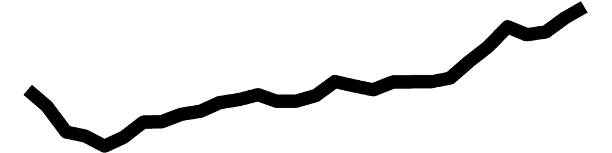

Croydon

24 December

England

28.2

7.3

10.4 ▲

2.7

County Durham

24 December

England

26.9

5.1

4.7 ▲

0.9

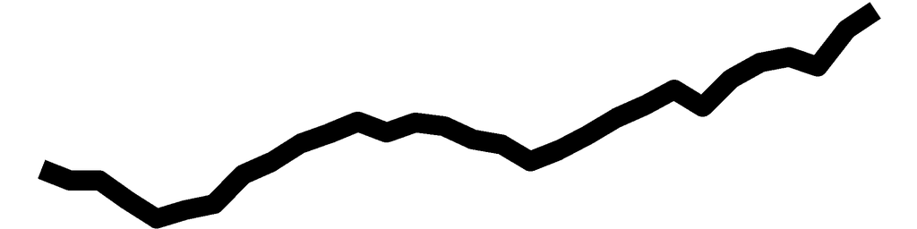

Enfield

24 December

England

23.4

7.0

8.5 ▲

2.5

Newham

24 December

England

22.5

6.4

8.8 ▲

2.5

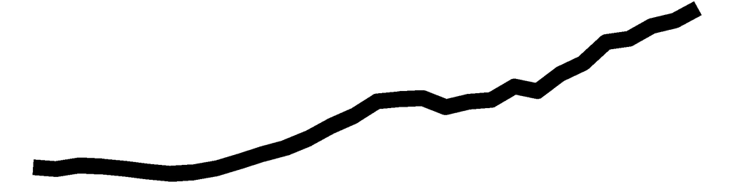

Redbridge

24 December

England

20.9

6.9

6.7 ▲

2.2

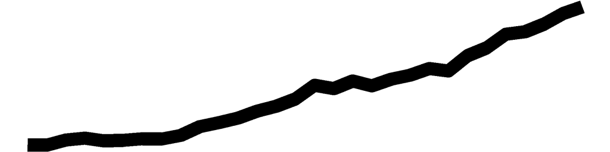

Greenwich

24 December

England

20.3

7.1

10.3 ▲

3.6

Hackney and City of London

24 December

England

20.2

7.0

9.5 ▲

3.3

Haringey

24 December

England

19.6

7.3

8.1 ▲

3.0

Lewisham

24 December

England

19.5

6.4

10.7 ▲

3.5

Data from NHS England | Analysis by @VictimOfMaths

<sup>*1*</sup> Data is only released once a week

```r
admratetable
```

Local Authorities in England with the highest rate of new admissions to hospital with COVID-19

Based on rolling 7-day average of both patients admitted with a positive test and those testing positive after admission

Local Authority

Data up to<sup>1</sup>

Country

Current admissions per day

Change in daily admissions in the last 7 days

Last month

Rate per 100,000

Total

Rate per 100,000

Total

Havering

24 December

England

7.3

18.9

1.9 ▲

5.0

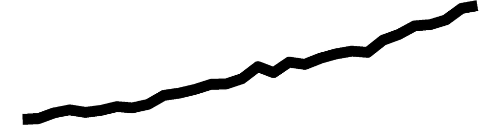

Croydon

24 December

England

7.3

28.2

2.7 ▲

10.4

Haringey

24 December

England

7.3

19.6

3.0 ▲

8.1

Barking and Dagenham

24 December

England

7.2

15.3

2.1 ▲

4.4

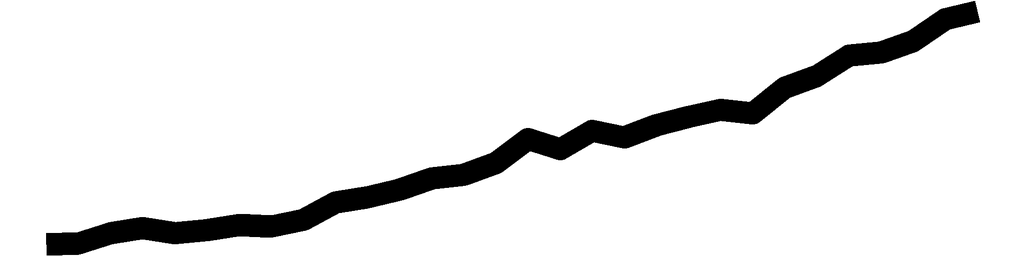

Greenwich

24 December

England

7.1

20.3

3.6 ▲

10.3

Hackney and City of London

24 December

England

7.0

20.2

3.3 ▲

9.5

Enfield

24 December

England

7.0

23.4

2.5 ▲

8.5

Brentwood

24 December

England

7.0

5.3

1.3 ▲

1.0

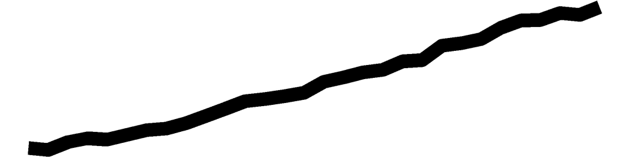

Redbridge

24 December

England

6.9

20.9

2.2 ▲

6.7

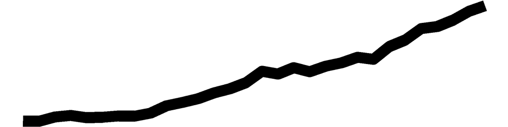

Barnsley

24 December

England

6.8

16.7

−1.2 ▼

−2.9

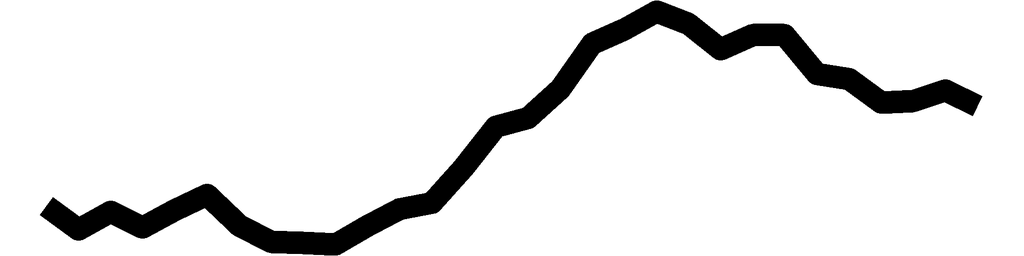

Data from NHS England | Analysis by @VictimOfMaths

<sup>*1*</sup> Data is only released once a week

```r
admchangetable
```

Local Authorities in the UK with biggest rise in new COVID-19 hospital admissions in the last week

Based on rolling 7-day average of both patients admitted with a positive test and those testing positive after admission

Local Authority

Data up to<sup>1</sup>

Country

Change in daily admissions in the last 7 days

Current admissions per day

Last month

Total

Rate per 100,000

Total

Rate per 100,000

Lewisham

24 December

England

10.7 ▲

3.5

19.5

6.4

Croydon

24 December

England

10.4 ▲

2.7

28.2

7.3

Greenwich

24 December

England

10.3 ▲

3.6

20.3

7.1

Hackney and City of London

24 December

England

9.5 ▲

3.3

20.2

7.0

Birmingham

24 December

England

9.1 ▲

0.8

44.4

3.9

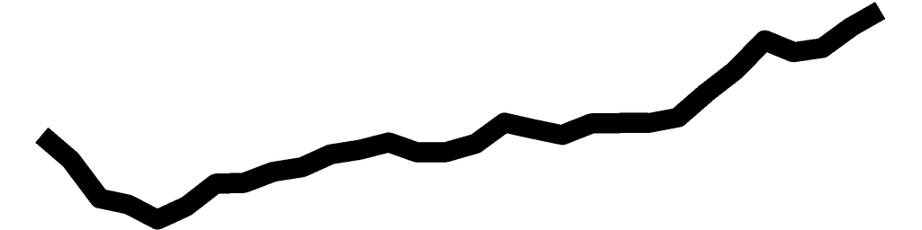

Newham

24 December

England

8.8 ▲

2.5

22.5

6.4

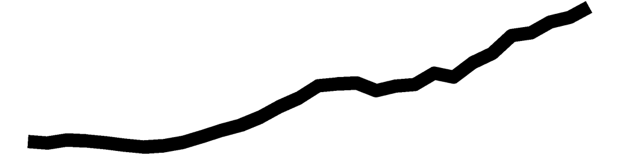

Bromley

24 December

England

8.7 ▲

2.6

12.8

3.9

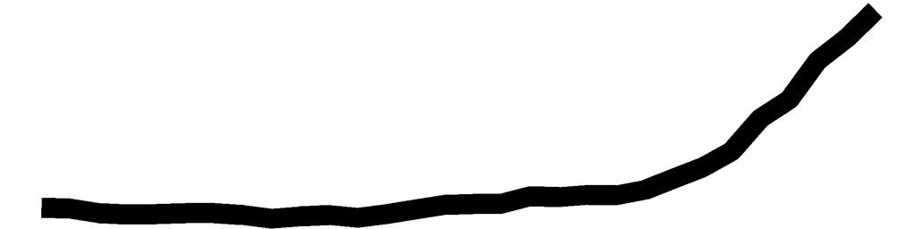

Enfield

24 December

England

8.5 ▲

2.5

23.4

7.0

Southwark

24 December

England

8.1 ▲

2.6

10.3

3.2

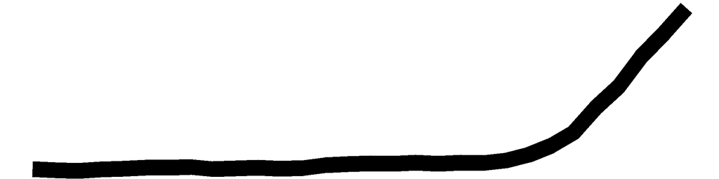

Haringey

24 December

England

8.1 ▲

3.0

19.6

7.3

Data from NHS England | Analysis by @VictimOfMaths

<sup>*1*</sup> Data is only released once a week

```r
admratechangetable
```

Local Authorities in the UK with biggest rise in new COVID-19 hospital admission rates in the last week

Based on rolling 7-day average of both patients admitted with a positive test and those testing positive after admission

Local Authority

Data up to<sup>1</sup>

Country

Change in daily admissions in the last 7 days

Current admissions per day

Last month

Rate per 100,000

Total

Rate per 100,000

Total

Greenwich

24 December

England

3.6 ▲

10.3

7.1

20.3

Lewisham

24 December

England

3.5 ▲

10.7

6.4

19.5

Hackney and City of London

24 December

England

3.3 ▲

9.5

7.0

20.2

Haringey

24 December

England

3.0 ▲

8.1

7.3

19.6

Bexley

24 December

England

2.7 ▲

6.8

6.5

16.0

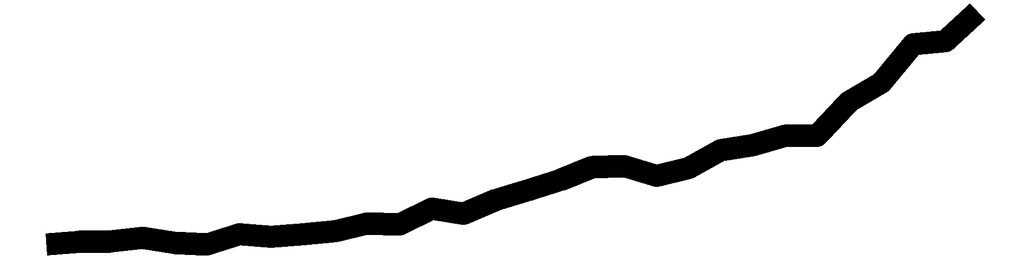

Croydon

24 December

England

2.7 ▲

10.4

7.3

28.2

Crawley

24 December

England

2.7 ▲

3.0

5.7

6.4

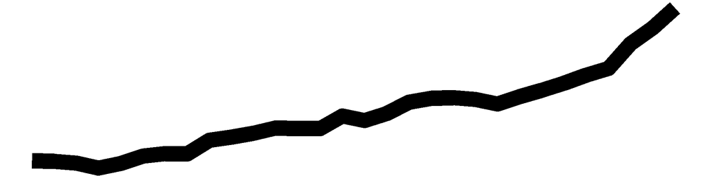

Tandridge

24 December

England

2.7 ▲

2.3

5.8

5.1

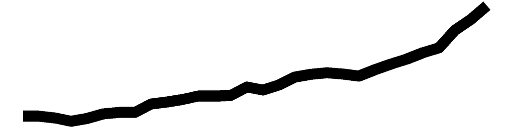

Bromley

24 December

England

2.6 ▲

8.7

3.9

12.8

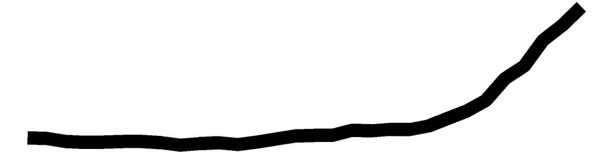

Waltham Forest

24 December

England

2.6 ▲

7.2

6.6

18.4

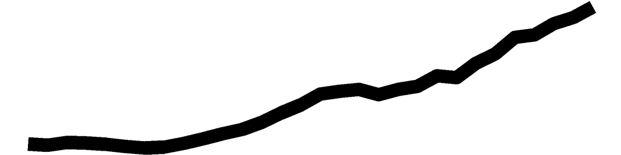

Data from NHS England | Analysis by @VictimOfMaths

<sup>*1*</sup> Data is only released once a week